# <strong>shinyr</strong> is developed to build dynamic shiny based dashboards to analyze the data of your choice. It provides simple yet genius dashboard design to subset the data, perform exploratory 

## Correlation Plot

You can use corrplot::corrplot() on correlation table to get the correlation table.

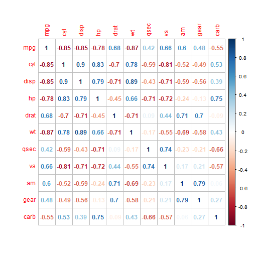

```r
corrplot::corrplot(as.matrix(res$cor_matrix),method = "number")
```

## Exclude few items from the given set

This function was developed to eliminate few items from the list of items for any reason.

```r
excludeThese(mtcars$mpg, c(21.0))
```

```
##  [1] 22.8 21.4 18.7 18.1 14.3 24.4 22.8 19.2 17.8 16.4 17.3 15.2 10.4 10.4 14.7
## [16] 32.4 30.4 33.9 21.5 15.5 15.2 13.3 19.2 27.3 26.0 30.4 15.8 19.7 15.0 21.4
```

## get most repeated item in the given set

You can find out most repeated values in the given set of values.

```r
getMostRepeatedValue(c(1,1,1,2,2,3,4,5))
```

```
## [1] 1
## Levels: 1 2 3 4 5
```

## Calculate total missing items in vector

missing count will calculate the total number of NA, NULL, “”, “NULL”, “NA” s in a given set of values. lets introduce some missing values to mtcars

```r
x <- head(mtcars)
x$mpg[1:2] <- NA
```

```r
missing_count(x$mpg)
```

```
## [1] 2
```

## Impute data

You can replace the missing values in any column of given data frame with one of mean, median, max, and min, sum and mode by using ImputeMydata(). for example you can impute the missing values in the mpg column by mean of all the values in the column as shown below.

```r
 imputeMyData(df = x, col = "mpg", FUN = "mean")
```

```
##                     mpg cyl disp  hp drat    wt  qsec vs am gear carb
## Mazda RX4         20.25   6  160 110 3.90 2.620 16.46  0  1    4    4
## Mazda RX4 Wag     20.25   6  160 110 3.90 2.875 17.02  0  1    4    4
## Datsun 710        22.80   4  108  93 3.85 2.320 18.61  1  1    4    1
## Hornet 4 Drive    21.40   6  258 110 3.08 3.215 19.44  1  0    3    1
## Hornet Sportabout 18.70   8  360 175 3.15 3.440 17.02  0  0    3    2
## Valiant           18.10   6  225 105 2.76 3.460 20.22  1  0    3    1
```

## Group By and Summarize

You can summarize the values of one column by grouping the values in the other column using groupByandSummarize(). For example you can calculate mean of hp by am.

```r
knitr::kable(groupByandSumarize(mtcars, grp_col = c("am"), summarise_col = "hp", FUN = "mean"))
```

| am | mean_of_hp_by_am |
| --- | --- |
| 1 | 126.8462 |
| 0 | 160.2632 |

## Data partition

You can split a given data set into training set and test set by using datapartition(), you can specify the percentage to specify the size of trainset. For example you can split mtcars into 85 percent to train and 15 to test as shown below.

```r
partition <- dataPartition(mtcars, 85)
```

partition is a list of length 2, which contains test and train sets.

### head of train set

```r
knitr::kable(head(partition$Train))
```

|  | mpg | cyl | disp | hp | drat | wt | qsec | vs | am | gear | carb |
| --- | --- | --- | --- | --- | --- | --- | --- | --- | --- | --- | --- |
| Cadillac Fleetwood | 10.4 | 8 | 472.0 | 205 | 2.93 | 5.25 | 17.98 | 0 | 0 | 3 | 4 |
| Merc 450SE | 16.4 | 8 | 275.8 | 180 | 3.07 | 4.07 | 17.40 | 0 | 0 | 3 | 3 |
| Volvo 142E | 21.4 | 4 | 121.0 | 109 | 4.11 | 2.78 | 18.60 | 1 | 1 | 4 | 2 |
| Datsun 710 | 22.8 | 4 | 108.0 | 93 | 3.85 | 2.32 | 18.61 | 1 | 1 | 4 | 1 |
| Hornet Sportabout | 18.7 | 8 | 360.0 | 175 | 3.15 | 3.44 | 17.02 | 0 | 0 | 3 | 2 |
| Merc 450SL | 17.3 | 8 | 275.8 | 180 | 3.07 | 3.73 | 17.60 | 0 | 0 | 3 | 3 |

### head of test set

```r
knitr::kable(head(partition$Test))
```

|  | mpg | cyl | disp | hp | drat | wt | qsec | vs | am | gear | carb |
| --- | --- | --- | --- | --- | --- | --- | --- | --- | --- | --- | --- |
| Merc 240D | 24.4 | 4 | 146.7 | 62 | 3.69 | 3.190 | 20.00 | 1 | 0 | 4 | 2 |
| Merc 230 | 22.8 | 4 | 140.8 | 95 | 3.92 | 3.150 | 22.90 | 1 | 0 | 4 | 2 |
| Honda Civic | 30.4 | 4 | 75.7 | 52 | 4.93 | 1.615 | 18.52 | 1 | 1 | 4 | 2 |
| Pontiac Firebird | 19.2 | 8 | 400.0 | 175 | 3.08 | 3.845 | 17.05 | 0 | 0 | 3 | 2 |
| Ferrari Dino | 19.7 | 6 | 145.0 | 175 | 3.62 | 2.770 | 15.50 | 0 | 1 | 5 | 6 |

## Train regression model

```r
mod <- lm(formula = wt ~ ., data = mtcars)
mod
```

```
##
## Call:
## lm(formula = wt ~ ., data = mtcars)
##
## Coefficients:
## (Intercept)          mpg          cyl         disp           hp         drat
##   -0.230634    -0.041666    -0.057254     0.006685    -0.003230    -0.090083
##        qsec           vs           am         gear         carb
##    0.199541    -0.066368     0.018445    -0.093508     0.248688
```

## Prediction

```r
predictions <- predict(mod, mtcars[,-6])
```

## Get Regression Model Metrics

get the metrics of regression model by using regressionModelmMetrics()

```r
 actials <- mtcars[,6]
 x <- regressionModelMetrics(actuals = actials, predictions = predictions, model = mod)
 y <- as.data.frame(x)
 row.names(y) <- NULL
 knitr::kable(y)
```

| AIC | BIC | MAE | MSE | RMSE | MAPE | Corelation | r.squared | adj.r.squared |
| --- | --- | --- | --- | --- | --- | --- | --- | --- |
| 20.01 | 37.6 | 0.18 | 0.05 | 0.23 | 0.06 | 0.97 | 0.94 | 0.92 |